# ASML EXAM Exercise 2

```r
library(ggplot2)
library(tidyverse)
```

```r
load(file = "test1.RData")
dat=data
attach(dat)
```

```r
head(dat)
```

|  | Y | X1 | X2 | X3 | X4 | X5 | X6 | X7 | X8 | X9 |
| --- | --- | --- | --- | --- | --- | --- | --- | --- | --- | --- |
| 1 | 3.404235 | 2.728574 | -2.523311 | 0.07239438 | 1.7666872 | 2.043437 | -1.034208037 | 1.518236 | -2.680846 | 0.87910953 |
| 2 | -1.183760 | 2.178786 | -1.067986 | 0.10536782 | 2.5711432 | 2.066383 | 0.000764487 | 1.858435 | -2.088712 | -0.12855739 |
| 3 | -13.545829 | 2.944898 | -1.816202 | 0.60125001 | 7.5190835 | -2.189691 | -0.006173326 | 1.841349 | -2.137484 | 0.06758215 |
| 4 | 9.634723 | 3.775000 | -1.502315 | 0.12060477 | 0.3039228 | 1.996586 | 1.039600486 | 2.711924 | -1.592087 | -0.39741008 |
| 5 | -21.820617 | 2.826521 | -2.699750 | 0.82284661 | 10.0795024 | 1.915885 | 0.575734468 | 1.979450 | -1.502592 | -0.64098059 |
| 6 | 3.381392 | 2.005854 | -2.619976 | 0.04924055 | 0.8674074 | -2.087304 | 0.737315246 | 2.115668 | -1.611627 | -0.13971496 |

### a) Perform the multiple regression model and analyse all the outputs that are available

```r
LM = lm(Y~.,data = dat)
```

Before analysing the outputs of test, we need to check assumptions on the noise

- Homoscedasticity: plot standardized residuals vs fitted values they seems spread equally along the ranges of predictors.
- Gaussianity: Normal QQPlot, majority of the points are on the line
- Independency: as we have no informations we assume they are independent

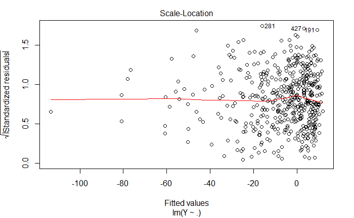

```r
plot(LM,3)
```

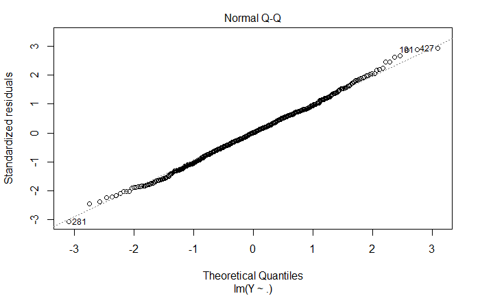

```r
plot(LM,2)
```

Analysis of the output:

```r
summary(LM)
```

```
Call:
lm(formula = Y ~ ., data = dat)

Residuals:
      Min        1Q    Median        3Q       Max
-0.298157 -0.063828  0.000327  0.064227  0.287811

Coefficients:
              Estimate Std. Error   t value Pr(>|t|)
(Intercept)  2.0261760  0.0377967    53.607   <2e-16 ***
X1           3.0023823  0.0076688   391.509   <2e-16 ***
X2          -0.0027336  0.0082289    -0.332   0.7399
X3          -0.0205566  0.0182475    -1.127   0.2605
X4          -3.0004636  0.0008108 -3700.703   <2e-16 ***
X5          -0.0022834  0.0022333    -1.022   0.3071
X6          -0.0063286  0.0030461    -2.078   0.0383 *
X7          -1.0158935  0.0093976  -108.101   <2e-16 ***
X8          -0.0024736  0.0089039    -0.278   0.7813
X9          -0.0041122  0.0090857    -0.453   0.6510
---
Signif. codes:  0 ‘***’ 0.001 ‘**’ 0.01 ‘*’ 0.05 ‘.’ 0.1 ‘ ’ 1

Residual standard error: 0.09893 on 490 degrees of freedom
Multiple R-squared:      1, Adjusted R-squared:      1
F-statistic: 1.567e+06 on 9 and 490 DF,  p-value: < 2.2e-16
```

- Adjusted R-squared = 1 –> all the variance can be explained by the model: use of linear model is ok.
- Fisher test p-value < 5% –> we reject H0 which is all parameters coefficients equal 0.
- X1, X4, X7 seems to be the more influent variables on the model.

### b) What are the variables that are really connected to the response variable

We are going to perform variable selection using a backward step by step method. this means we are going to consider the full model and remove at each step the worst explanatory variable until no further improvement.

for selecting which variable to remove we will use the AIC (Akaike information criterion)
$$AIC = 2k - 2ln(\widehat{L})$$

```r
step(LM,direction = "backward")
```

```
Start:  AIC=-2303.39
Y ~ X1 + X2 + X3 + X4 + X5 + X6 + X7 + X8 + X9

       Df Sum of Sq    RSS      AIC
- X8    1         0      5 -2305.31
- X2    1         0      5 -2305.28
- X9    1         0      5 -2305.18
- X5    1         0      5 -2304.33
- X3    1         0      5 -2304.10
<none>                   5 -2303.39
- X6    1         0      5 -2301.01
- X7    1       114    119  -698.99
- X1    1      1500   1505   569.01
- X4    1    134050 134055  2813.70

Step:  AIC=-2305.31
Y ~ X1 + X2 + X3 + X4 + X5 + X6 + X7 + X9

       Df Sum of Sq    RSS      AIC
- X2    1         0      5 -2307.19
- X9    1         0      5 -2307.12
- X5    1         0      5 -2306.27
- X3    1         0      5 -2306.08
<none>                   5 -2305.31
- X6    1         0      5 -2302.79
- X7    1       114    119  -700.89
- X1    1      1501   1505   567.08
- X4    1    134234 134239  2812.39

Step:  AIC=-2307.19
Y ~ X1 + X3 + X4 + X5 + X6 + X7 + X9

       Df Sum of Sq    RSS      AIC
- X9    1         0      5 -2309.00
- X5    1         0      5 -2308.11
- X3    1         0      5 -2307.96
<none>                   5 -2307.19
- X6    1         0      5 -2304.69
- X7    1       114    119  -702.63
- X1    1      1502   1507   565.68
```

[output cut: 26 more lines]

```
Y ~ X1 + X4 + X6 + X7

       Df Sum of Sq    RSS      AIC
<none>                   5 -2310.67
- X6    1         0      5 -2308.42
- X7    1       115    120  -707.04
- X1    1      1519   1524   565.15
- X4    1    135917 135922  2810.61

Call:
lm(formula = Y ~ X1 + X4 + X6 + X7, data = dat)

Coefficients:
(Intercept)           X1           X4           X6           X7
   2.031093     3.002212    -3.000366    -0.006202    -1.015735
```

- we can see that variables explaining the response are X1, X4, X6 and X7.

```r
LMbest = lm(Y~X1+X4+X6+X7,data = dat)
summary(LMbest)
```

```
Call:
lm(formula = Y ~ X1 + X4 + X6 + X7, data = dat)

Residuals:
      Min        1Q    Median        3Q       Max
-0.285588 -0.066303  0.000747  0.065736  0.287570

Coefficients:
              Estimate Std. Error   t value Pr(>|t|)
(Intercept)  2.0310926  0.0295953    68.629   <2e-16 ***
X1           3.0022119  0.0076034   394.852   <2e-16 ***
X4          -3.0003658  0.0008033 -3735.142   <2e-16 ***
X6          -0.0062016  0.0030189    -2.054   0.0405 *
X7          -1.0157352  0.0093561  -108.564   <2e-16 ***
---
Signif. codes:  0 ‘***’ 0.001 ‘**’ 0.01 ‘*’ 0.05 ‘.’ 0.1 ‘ ’ 1

Residual standard error: 0.0987 on 495 degrees of freedom
Multiple R-squared:      1, Adjusted R-squared:      1
F-statistic: 3.542e+06 on 4 and 495 DF,  p-value: < 2.2e-16
```